# DA 101 Lec 11

Your Name

07 October, 2019

## Confidence Intervals

CIs are methods of statistical inference, just hyp test.

Wait, what’s inference? It’s making an educated guess, i.e., basing our prediction on evidence and reason.

Statistical inference is the process of making conclusions about our populations, based on the sample data we take (and using probability).

There are two main types: hyp tests **ask a question** about a population. Is the mean bigger? Is there a difference? Etc… We’ve seen these.

CIs are the other type of inference: we use them for making an **estimate**. Generally, “estimate” and “make a confidence interval” are synonymous.

### The idea

According to CLT, sample stats (like the mean) always follow normal distributions (for large samples). In hyp tests, we center our bell curve on the null hypothesis (out assumption).

CIs are the other way around: we center our bell curve around our ** sample result**.

In short, CIs give us a reasonable range of values for the population based on our sample data and probability.

NOTE: CIs and Hyp Tests always give the same conclusion!! I.e., a 95% CI is equivalent to a hyp test with alpha = .05. More on this later.

### Examples: `mpg`, `iris`

First, let’s do a confidence interval for one mean. Our goal: estimate the mean Sepal Length of the iris flowers.

```r
iris %>% head
```

|  | Sepal.Length | Sepal.Width | Petal.Length | Petal.Width | Species |
| --- | --- | --- | --- | --- | --- |
| 1 | 5.1 | 3.5 | 1.4 | 0.2 | setosa |
| 2 | 4.9 | 3.0 | 1.4 | 0.2 | setosa |
| 3 | 4.7 | 3.2 | 1.3 | 0.2 | setosa |
| 4 | 4.6 | 3.1 | 1.5 | 0.2 | setosa |
| 5 | 5.0 | 3.6 | 1.4 | 0.2 | setosa |
| 6 | 5.4 | 3.9 | 1.7 | 0.4 | setosa |

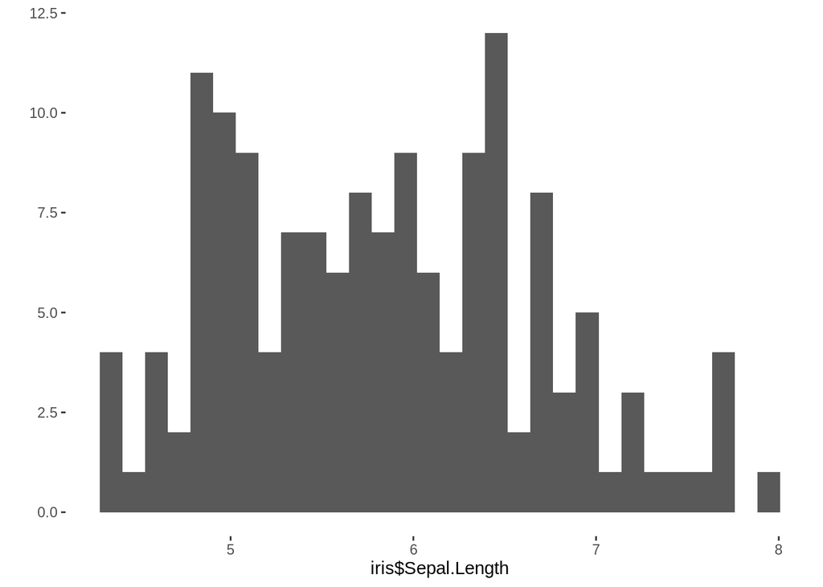

```r
qplot(iris$Sepal.Length)
```

In R, CIs are made automatically by ‘t.test()’ command.

```r
t.test(iris$Sepal.Length)
```

```
##
##  One Sample t-test
##
## data:  iris$Sepal.Length
## t = 86.425, df = 149, p-value < 2.2e-16
## alternative hypothesis: true mean is not equal to 0
## 95 percent confidence interval:
##  5.709732 5.976934
## sample estimates:
## mean of x
##  5.843333
```

(Note: Ha: mu !=0. Since there’s only one variable, R assumes 0 by default.)

The important part: The CI. Here, (5.7097, 5.9769). What does this mean? This:

We are 95% confident that the true population mean Sepal Length for the iris flowers is between 5.7097 and 5.9769.

The upshot: we now have an estimate for the whole population!

Explicitly, the sample mean is:

```r
mean(iris$Sepal.Length)
```

```
## [1] 5.843333
```

The CI we found is centered around this point estimate.

Jon’s question: Let’s compare species (2-samp CI)

```r
iris %>% filter(Species == "virginica") -> virginicaData
iris %>% filter(Species == "setosa") -> setosaData
```

Let’s do t.test/CI in sepal length for these two groups:

```r
t.test(setosaData$Sepal.Length, virginicaData$Sepal.Length)
```

```
##
##  Welch Two Sample t-test
##
## data:  setosaData$Sepal.Length and virginicaData$Sepal.Length
## t = -15.386, df = 76.516, p-value < 2.2e-16
## alternative hypothesis: true difference in means is not equal to 0
## 95 percent confidence interval:
##  -1.78676 -1.37724
## sample estimates:
## mean of x mean of y
##     5.006     6.588
```

We’re 95% confident that the difference in mean sepal length between the species is between -1.786 and -1.377. Based on this interval, it is very unlikely that the difference is zero. In other words, we conclude that there is strong evidence of a difference. Note: agrees with the p-val!!

Further: since the difference must be negative, we suspect that the second one must be larger (i.e virginicas have longer sepal length).

### Connection to Hyp Tests

Hyp tests and CIs always give the same result. Here’s how it works:

If the H0 value is contained in the CI, then we fail reject H0. It seems reasonable!

In the sepal length example, the null hyp: mu1-mu2=0. The CI was (-1.79, -1.38). Since zero is not contained in the CI, we reject H0. There’s strong evidence of a difference. The end.

## Error Types

Our tools (CIs and hyp tests) are based on data and math, but that doesn’t mean that we always get the correct result. Maybe, due to random chance or a bad sample or some other issue, the conclusion of the test could be wrong.

It’s very, very important for us to consider what that might mean. There are two possibilities:

Type I error (a false positive). “Positive result” means we reject H0, because that supports our claim! Type I error is when we reject H0, but in fact the null hyp was true! We were wrong!

(Note: in real life, it’s almost impossible to know the truth).

Type II error (a false negative): we fail to reject H0, but we should have becasue H0 is false.

### Hypothetical Examples (Worksheet)

1. EPA enforcement: we wonder if concentrations of Toxin A are above the safe level of 0.8 g/ml.

$$H_0:\mu = .8$$

$$H_a: \mu > .8$$

Type 1: We think the water is dangerous, but in fact it’s not.

Type 2: We think the water’s fine, but actually it’s dangerous.

Here, type 2 sounds much worse! People would drink dangerous water! I would feel bad about that, because I have human feelings.

In type 1, we merely waste money cleaning up water that’s already clean. If you value money more than human life (some humans do), then you’d think a type 1 is worse.

2. Judge at a criminal trial. We assume innocent by default, but the trial is designed to find evidence of guilt.

H0: Innocent Ha: Guilty

Type I: We reject H0. I.e., we reject the claim that they’re innocent. We’re supporting the alterate; we think that they’re guilty. In reality, the null hyp is true. Thus, the defendent is innocent!

All together: we thought they were guilty, but actually they’re innocent.

Type II: We fail to reject H0. Not enough evidence to conclude guilty. In reality, H0 is false, i.e. they’re guilty.

All together: we think they’re innocent, when actually they’re guilty.

Which is worse? Sending an innocent person to jail, or letting a criminal go free?

Prof Miller’s take: I haven’t committed any “serious” crimes. I’d be very upset if went to jail!

On the other hand, maybe the person is super super bad and….. we really, really don’t want them to go free.

3. Federal funding program. To qualify, neighborhoods must have mean income less than $15k.

H0: mu = 15000 (note: H0 always =) Ha: mu < 15000

Type I: Reject H0, so yes, we think they get funding. In actuality, the mean income is 15k or above.

Type II: We don’t think they qualify for funding, but actually the mean income is <15k so they do qualify!

In type I, we waste public funds on people who don’t need them. In type II, people who need help don’t get it!

4. Coffee cup is talking to you (?). Test with audio evidence.

H0: Your coffee cup is not talking to you. Ha: Your coffee cup is talking to you.

Type I error: We think it’s talking to us, but it’s not.

Type II: We don’t think it’s talking to us, but it is.

Prof Miller: Type II is worse.

### alpha

For a particular hyp test, alpha is the prob of making a type I error.

Note: this is the same as the significance level!!!! Woah! In other words, WE CHOOSE ALPHA! We choose the probability of a type I error!

### beta

Beta is the probabilty of a type II error.

Unfortunately, it’s (generally) impossible to know beta. The problem is this:

If beta, then type II error. If type II error, null hyp is false! If null hyp is false, then **we can’t find probablities** (like p-val).

Even though the math is tough; one fact is clear: bigger alpha makes beta smaller. And, smaller alpha makes beta bigger.

So, there’s always a balancing act! We can’t eliminate error entirely, but we can tip the scales!

We’ve seen that sometimes Type I is worse, sometimes Type II is worse. This depends on your human values and feelings! If type I is really bad: choose alpha smaller. If type II is really bad, choose alpha bigger.

### Power of a hyp test

The power of a hyp test is the probabilty of correctly rejecting the null hypothesis. I.e., the prob of reject H0 when H0 really is false.

Recall: we’re hoping to reject H0, since that gives evicence to support our claim! So, power is the prob of a “successful” hyp test!

Important relationship with power, beta:

```
  power = 1 - beta

  beta = 1-power
```

They’re complements! That means, there’s a price to pay for high power: type I error is more likely too!

## Factors affecting alpha, beta, and power

### Sample Size

Bigger n means bigger power! Thank goodness! That means, sample size provides a certain control over power. Of course, larger samples are more expensive, more time consuming, maybe not available at all.

### Significance level

Remember you choose alpha.

Bigger alpha means smaller beta.

Bigger alpha means bigger power.

It’s a balance! You have to chose.

## Connection btwn Conf Int MOE and Hyp Test alpha

CIs are centered at the sample result, and the width is the MOE. But, Confidence level (i.e. 95%) is the opposite of alpha (i.e. alpha = 0.05).

If confidence level increses (say, to 99%), what effect does that have on alpha, beta, and power?

### Connection between CI and Hyp Test Errors